# RMarkdown_Project1

kks_git

2023-12-22

A. Loading and preprocessing the data

1. Load the Data

```r
data<-".\\activity.csv"
dataP1<-read.csv(data, header=TRUE)
```

2. Process/transform the Data

```r
dataP1$date<-as.Date(x=dataP1$date, format="%Y-%m-%d")
```

B. What is mean total number of steps taken per day?

1. Calculate the total number of steps taken per day

```r
dailySteps<-aggregate(steps~date, data=dataP1, FUN=sum)
```

2. Make a histogram of the total number of steps taken each day

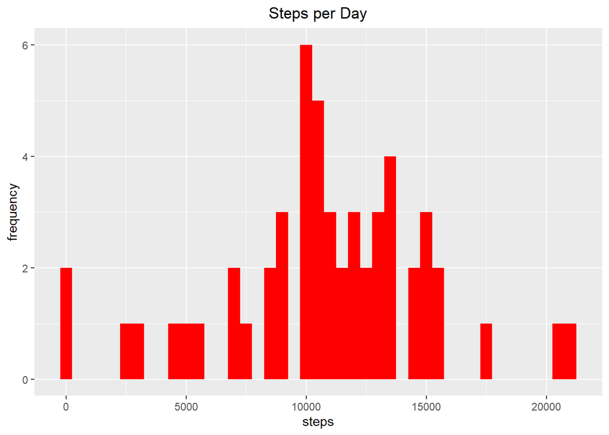

```r
steps_hist<-ggplot(data = dailySteps, aes(x=steps)) +geom_histogram(fill="red", binwidth=500)+labs(title="Steps per Day", x="steps",y="frequency")+theme(plot.title = element_text(hjust=0.5))
steps_hist
```

3. Calculate and report the mean and median of the total number of steps taken per day

```r
stepsMean<-mean(dailySteps$steps, na.rm=TRUE)
stepsMean
```

```
## [1] 10766.19
```

```r
stepsMedian<-median(dailySteps$steps, na.rm=TRUE)
stepsMedian
```

```
## [1] 10765
```

C. What is the average daily activity pattern?

1. Make a time series plot (i.e. type = “l”) of the 5-minute interval (x-axis) and the average number of steps taken, averaged across all days (y-axis)

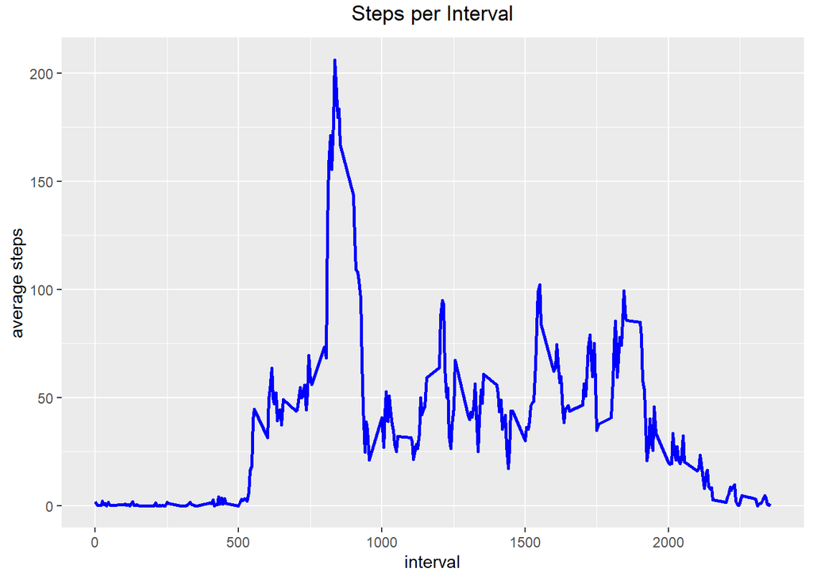

```r
stepsInterval<-aggregate(steps~interval, data = dataP1, FUN = mean)
timeSeries_plot<-ggplot(stepsInterval, aes(x=interval, y=steps)) +geom_line(color="blue", linewidth=1)+labs(title="Steps per Interval", x="interval", y="average steps") +theme(plot.title = element_text(hjust=0.5, vjust = 2))
timeSeries_plot
```

2. Which 5-minute interval, on average across all the days in the dataset, contains the maximum number of steps?

```r
maxInterval<-stepsInterval[which.max(stepsInterval$steps),]
maxInterval
```

```
##     interval    steps
## 104      835 206.1698
```

D. Imputing missing values